# Course Project 1

Alberto Chong

12/29/2020

### libraries

We will attach the following libraries:

```r
library(dplyr)
library(ggplot2)
library(tidyr)
```

### 1. Loading and preprocessing the data

#### Loading data

```r
activity <- read.csv(unzip(paste0(getwd(),"/activity.zip")))
```

#### transform data

```r
activity <- activity %>% mutate(date = as.Date(date))
str(activity)
```

```
## 'data.frame':    17568 obs. of  3 variables:
##  $ steps   : int  NA NA NA NA NA NA NA NA NA NA ...
##  $ date    : Date, format: "2012-10-01" "2012-10-01" ...
##  $ interval: int  0 5 10 15 20 25 30 35 40 45 ...
```

### 2. What is mean total number of steps taken per day?

#### Calculate the total number of steps taken per day

```r
Total <- activity %>%
    group_by(date) %>%
    summarise(total = sum(steps,na.rm = TRUE)) %>%
    ungroup()
head(Total)
```

```
## # A tibble: 6 x 2
##   date       total
##   <date>     <int>
## 1 2012-10-01     0
## 2 2012-10-02   126
## 3 2012-10-03 11352
## 4 2012-10-04 12116
## 5 2012-10-05 13294
## 6 2012-10-06 15420
```

#### Make a histogram of the total number of steps taken each day

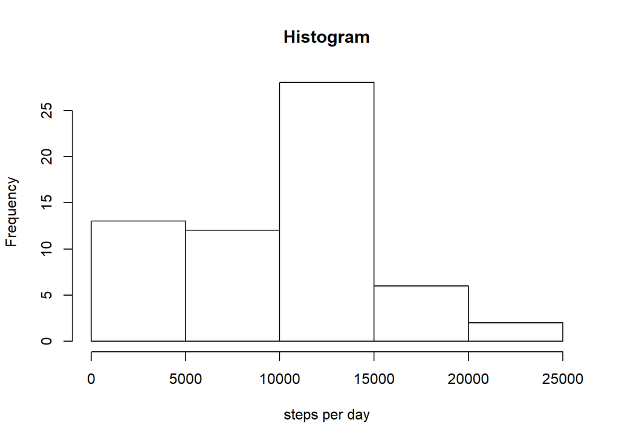

```r
hist(Total$total,
     main = "Histogram",
     xlab = "steps per day")
```

### 3. Calculate and report the mean and median of the total number of steps taken per day

Mean of total number of steps per day

```r
mean(Total$total)
```

```
## [1] 9354.23
```

Median of total number of steps

```r
median(Total$total)
```

```
## [1] 10395
```

### 4. What is the average daily activity pattern?

#### Time series plot

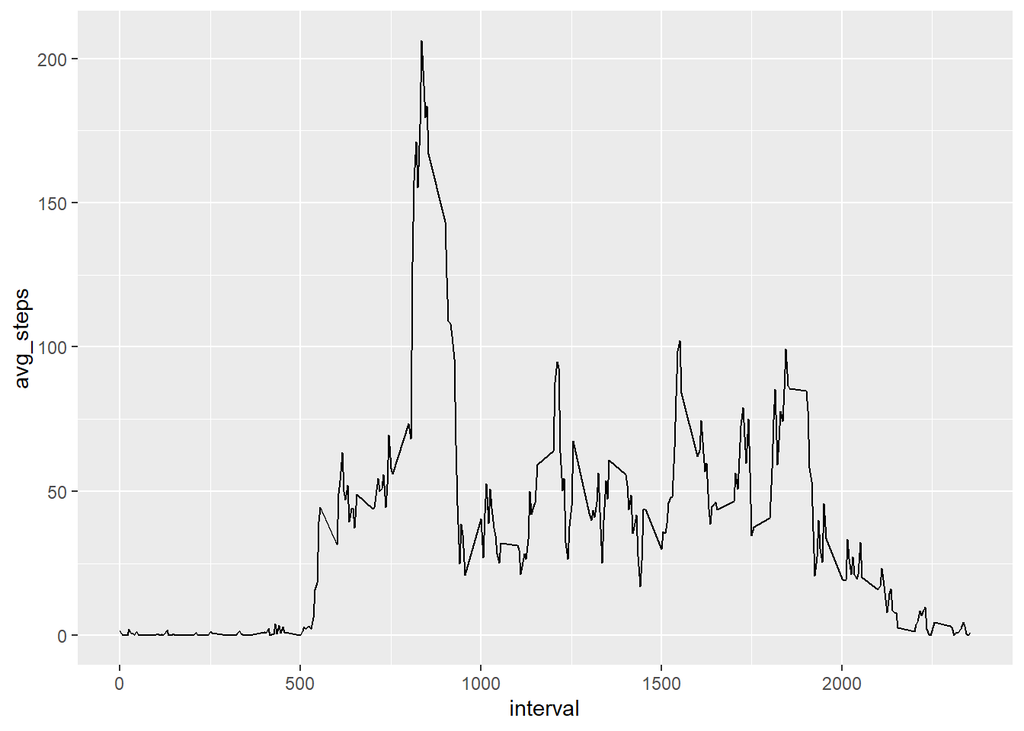

```r
activity %>% group_by(interval) %>%
  summarise(avg_steps = mean(steps,na.rm = T)) %>%
  ggplot(aes(x = interval, y = avg_steps)) +
  geom_line()
```

### 5. 5-minute interval that contains the maximum number of steps on average

```r
avg_interval <- activity %>% group_by(interval) %>%
    summarise(avg_steps = mean(steps,na.rm = T))
avg_interval[which(avg_interval$avg_steps == max(avg_interval$avg_steps,na.rm = T)),]
```

```
## # A tibble: 1 x 2
##   interval avg_steps
##      <int>     <dbl>
## 1      835      206.
```

### 6. Imputing missing values

#### Calculate and report the total number of missing values in the dataset

```r
sum(is.na(activity$steps))
```

```
## [1] 2304
```

#### Strategy for filling in all of the missing values in the dataset

```r
avg_day <- activity %>%
    group_by(date) %>%
    summarise(avg = round(mean(steps, na.rm = TRUE),0)) %>%
    ungroup() %>%
    replace_na(list(avg = 0))
head(avg_day)
```

```
## # A tibble: 6 x 2
##   date         avg
##   <date>     <dbl>
## 1 2012-10-01     0
## 2 2012-10-02     0
## 3 2012-10-03    39
## 4 2012-10-04    42
## 5 2012-10-05    46
## 6 2012-10-06    54
```

#### Create a new dataset that is equal to the original dataset but with the missing data filled in

```r
imputed_activity <- activity %>%
    inner_join(avg_day, by = "date") %>%
    mutate(steps = ifelse(is.na(steps),avg,steps)) %>%
    select(-avg)

head(imputed_activity)
```

```
##   steps       date interval
## 1     0 2012-10-01        0
## 2     0 2012-10-01        5
## 3     0 2012-10-01       10
## 4     0 2012-10-01       15
## 5     0 2012-10-01       20
## 6     0 2012-10-01       25
```

### 7. Make a histogram of the total number of steps taken each day and Calculate and report the mean and median total number of steps taken per day

Histogram

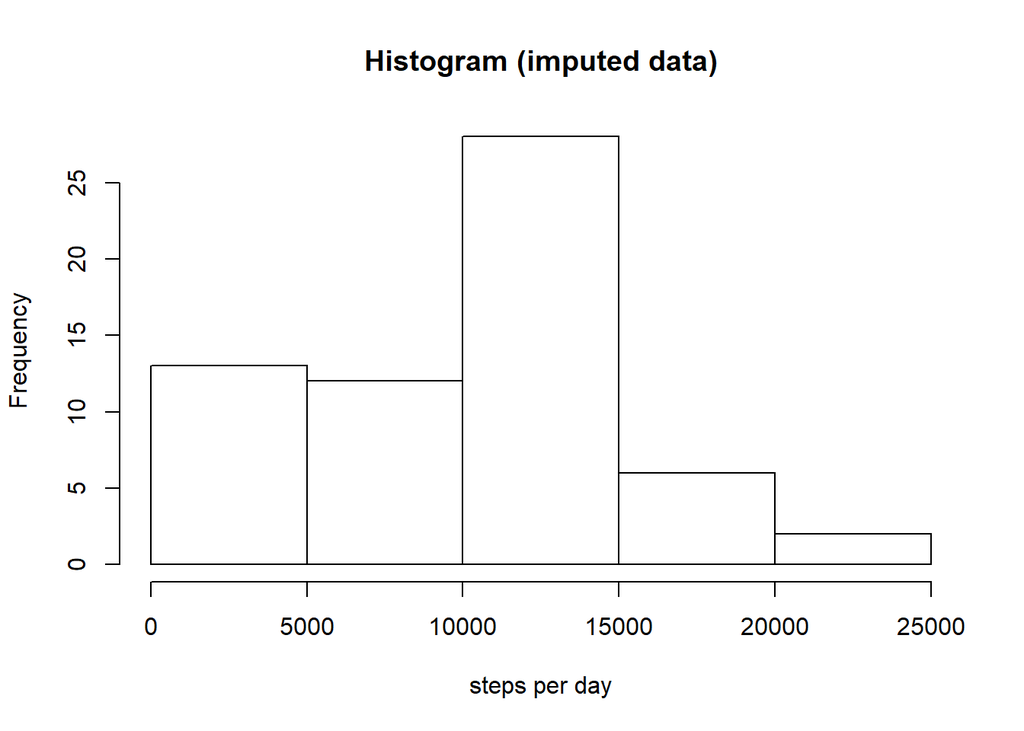

```r
imputed_Total <- imputed_activity %>%
    group_by(date) %>%
    summarise(total = sum(steps,na.rm = TRUE)) %>%
    ungroup()
hist(imputed_Total$total,
     main = "Histogram (imputed data)",
     xlab = "steps per day")
```

Mean:

```r
mean(imputed_Total$total)
```

```
## [1] 9354.23
```

Median:

```r
median(imputed_Total$total)
```

```
## [1] 10395
```

The values of mean an median didn’t change from the estimates calculated from the first part of the assigment.

### 8. Are there differences in activity patterns between weekdays and weekends?

#### Create a new factor variable in the dataset with two levels - “weekday” and “weekend”

```r
imputed_activity$weekday <- weekdays(imputed_activity$date)
imputed_activity <- imputed_activity %>%
    mutate(class_weekday = ifelse(weekday %in% c("Saturday","Sunday"),"weekend","weekday"))
head(imputed_activity)
```

```
##   steps       date interval weekday class_weekday
## 1     0 2012-10-01        0  Monday       weekday
## 2     0 2012-10-01        5  Monday       weekday
## 3     0 2012-10-01       10  Monday       weekday
## 4     0 2012-10-01       15  Monday       weekday
## 5     0 2012-10-01       20  Monday       weekday
## 6     0 2012-10-01       25  Monday       weekday
```

#### Make a panel plot containing a time series plot

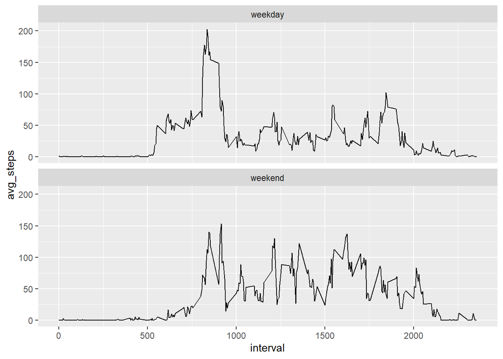

```r
imputed_activity %>%
  group_by(interval,class_weekday) %>%
  summarise(avg_steps = mean(steps,na.rm = T)) %>%
  ggplot(aes(x = interval, y = avg_steps)) +
  geom_line() +
  facet_wrap(~class_weekday, dir = "v")
```